# Barbiero_Lorenzo_rlab06

Barbiero Lorenzo

2023-06-04

```r
library(tidyverse)
library(ggpubr)
library(rjags)
library(runjags)
```

```r
library(tidybayes)
library(bayesplot)
```

## Exercise 1

```r
set.seed(80135)
```

Define and plot the custom posterior

```r
cpost <- function(x) {return(0.5*exp(-0.5*(x-3)**2)+0.5*exp(-0.5*(x+3)**2))}
```

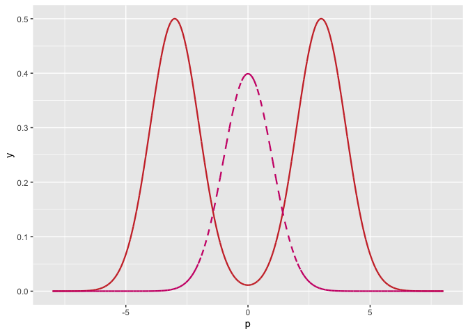

```r
p <- seq(-8,8,0.001)
y <- cpost(p)
td <- dnorm(p,0,1)
df <- data.frame(p,y,td)
(plt <- ggplot(df)+geom_line(aes(p,y), color="brown3", lwd=0.8)+geom_line(aes(p,td), linetype="dashed", color="deeppink3", lwd=0.8))
```

Define function for MCMC

```r
MCMC <- function(post, sigma, Nit, lowlim, highlim) {
  x <- runif(Nit,lowlim,highlim)
  sample <- post(x)
  dens <- rnorm(Nit,0,sigma)
  chain <- rep(0,Nit)
  ar <- Nit
    for (i in seq(1,length(sample)-1)) {

      targp <- (sample[i+1]/sample[i])*(dens[i+1]/dens[i])

      if (targp < 1) {
        extraction <- runif(1,0,1)
        if (extraction < targp) {
          chain[i] <- x[i+1]
        }
        else {
          chain[i] <- x[i]
          x[i+1] <- x[i]
          sample[i+1] <- sample[i]
          dens[i+1] <- dens[i]
          ar <- ar -1
        }
      }
      else {
        chain[i] <- x[i+1]
      }
    }
  acc_rate <- ar/Nit

  MCres <- list("chain"=chain, "acc_rt"=acc_rate)
  return(MCres)
}
```

```r
MC <- MCMC(cpost,1,1000000,-10,10)
chain <- data.frame(MC$chain)
colnames(chain) <- "Counts"
```

Acceptance rate of the chain

```r
(MC$acc_rt)
```

```
## [1] 0.115044
```

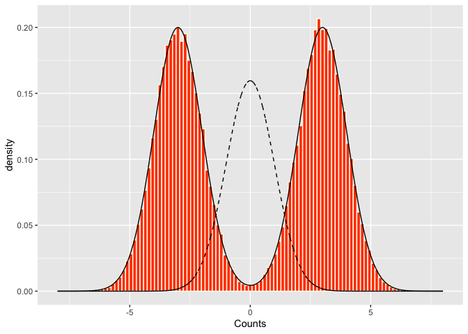

```r
(plt <- ggplot()+geom_histogram(data = chain, aes(Counts,after_stat(density)), binwidth=0.15, fill="orangered", color="ivory") + geom_line(data = df, aes(p,y/2.5))+geom_line(data= df, aes(p,td/2.5), linetype="dashed"))
```

```r
#posterior and density estimate rescaled for graphical purposes
```

### Auto Correlation

Using the coda package I will analyze the autocorrelation between samples in the chain

```r
c.MC <- as.mcmc(MC$chain)
lgs <- seq(0,150,10)
acf <- autocorr(c.MC,lgs)
dat <- data.frame(lgs,acf)
```

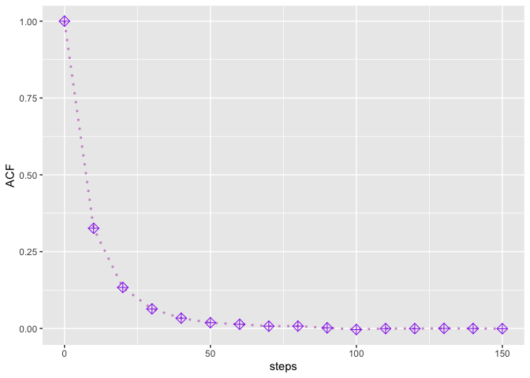

```r
(plt <- ggplot(dat)+geom_line(aes(lgs,acf), lwd=1, linetype="dotted", color="plum3")+geom_point(aes(lgs,acf), size=3, shape=9, color="purple2")+ labs(x="steps", y="ACF"))
```

Samples become decorrelated after about 50 steps, the effective size is

```r
(floor(effectiveSize(c.MC)))
```

```
##  var1
## 50877
```

### Thinning and burn-in

Two other relevant parameters for optimizing a MCMC algorithm are the burn-in, meaning the number of steps “ignored” by the sampling at the beginning and the thinning, meaning the number of steps between two samplings. To provide concise results I will repackage the whole analysis done above into a single function and provide only the relevant plots and quantities

```r
parest <- function(burn_in,thinning,chain) {

  p <- seq(-8,8,0.001)
  y <- cpost(p)
  td <- dnorm(p,0,1)
  df <- data.frame(p,y,td)

  #remove first burn in rows
  chain <- chain[-(1:burn_in)]
  #remove rows at thinning rate
  chain <- chain[seq(1,length(chain),thinning)]

  chain <- data.frame(chain)
  colnames(chain) <- "Counts"

  c.MC <- as.mcmc(chain)
  lgs <- seq(0,75,5)
  acf <- autocorr(c.MC,lgs)
  efs <- floor(effectiveSize(c.MC))
  label <- paste("Effective size:",efs)
  dat <- data.frame(lgs,acf)

  p1 <- ggplot() + geom_line(data = df, aes(p,y/2.5), color="brown3", linetype="dashed", lwd=0.7) + geom_histogram(data = chain, aes(Counts,after_stat(density)), binwidth=0.3, fill="orangered", color="ivory")
#posterior and density estimate rescaled for graphical purposes

  p2 <- ggplot(dat)+geom_line(aes(lgs,acf), lwd=1, linetype="dotted", color="plum3")+geom_point(aes(lgs,acf), size=3, shape=9, color="purple2")+ labs(x="steps", y="ACF") + annotate(geom="text", x=35, y=0.6, label=label)

  plt <- ggarrange(p1,p2, nrow = 1, ncol = 2)
  return(plt)
}
```

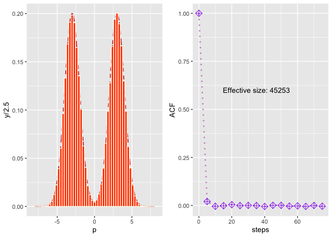

```r
(parest(1000,10,MC$chain))
```

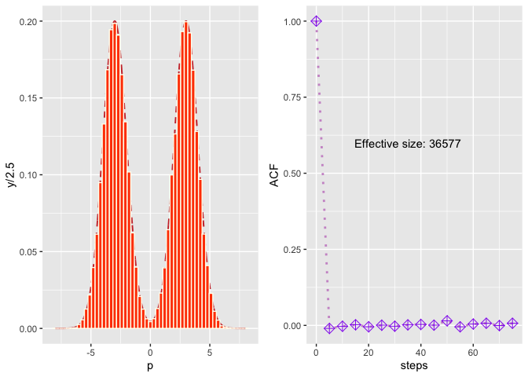

```r
(parest(1000,20,MC$chain))
```

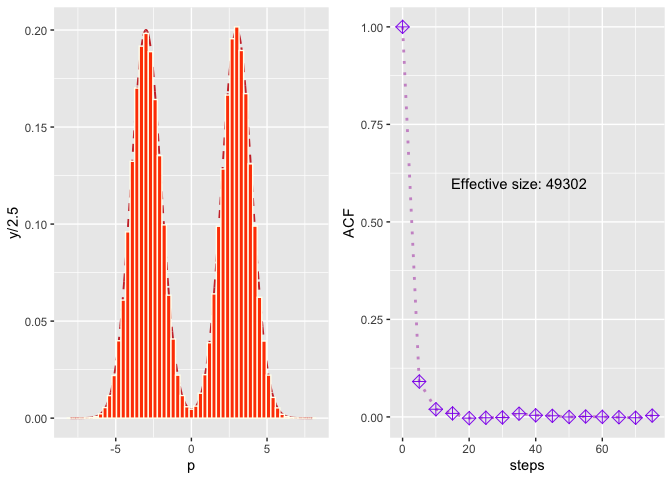

```r
(parest(1000,5,MC$chain))
```

Thinning = 10 seems to be a good trade off between effective size of the sample and decorrelation between datapoints

## Exercise 2

Following the general framework introduced during class we can sum everything up in a couple of functions

```r
efficacy_analysis <- function(tot_vaccine, tot_placebo, pos_vaccine, pos_placebo){

    patient <- c(rep(" Vaccine ", tot_vaccine ),
    rep(" Placebo ", tot_placebo ))
    tested <- c(rep("Pos", pos_vaccine ),
    rep("Neg", tot_vaccine - pos_vaccine ),
    rep("Pos", pos_placebo ),
    rep("Neg", tot_placebo - pos_placebo ))
    vax.tb <- tibble( tested = tested , patient = patient )
    table( vax.tb[[2]], vax.tb[[1]])

    modelString <- "
    model {
    for ( i in 1:Ntot ) {
    tested[i] ~ dbern( theta[ patient [i]] )
    }
    for ( k in 1: Nclass ) {
    theta[k] ~ dbeta(3 , 100)
    }
    }"

    dataList = list(
        tested = ifelse(vax.tb$tested == "Neg", 0, 1),
        patient = as.integer ( factor(vax.tb$patient )),
        Ntot = nrow(vax.tb) ,
        Nclass = nlevels (factor( vax.tb$patient )) )

    vax_chains <- run.jags( modelString ,
                            sample = 15000,
                            n.chains = 4,
                            method = "parallel",
                            monitor = "theta",
                            data = dataList);


    summary (vax_chains)

    vax_res <- tidybayes :: tidy_draws(vax_chains ) |> select ('theta[1]':'theta[2]') |>
                                                       rename ( Placebo = 'theta[1]', Vaccine = 'theta[2]') |>
                                                       mutate (diff_rate = ( Placebo - Vaccine ) / Placebo * 100,
                                                               Placebo_perc = Placebo * 100,
                                                               Vaccine_perc = Vaccine * 100)

    allmcmc2 <- as.mcmc(vax_res , vars="diff_rate")
    return(allmcmc2)
}
```

```r
plotPosterior <- function(samples, ci_perc, color, title) {

    # Convert samples to numeric
    samples <- as.numeric(samples)
    df <- data.frame(samples)

    # Calculate credibility interval
    ci <- quantile(samples, probs = c((1-ci_perc)/2, 1-(1-ci_perc)/2))
    ci <- as.numeric(ci)

    results_df <- data.frame(
    Mean = format(mean(samples), digits = 3),
    Std = format(sd(samples), digits = 3),
    C.Interval = paste('min:',format(ci[1], digits = 3), '  ','max:' ,format(ci[2], digits = 3)) )

    # Plot the histogram
    plot <- ggplot(df, aes(x = samples)) +
    geom_histogram(binwidth = 0.5, aes(y = after_stat(density)), fill = color, color = 'black') +
    labs(title = title, x = "Efficacy", y = "Frequency") +

    # Add credibility interval lines
    geom_segment(aes(x = ci[1], xend = ci[1], y = 0, yend = Inf), col = "black", lwd = 1) +
    geom_segment(aes(x = ci[2], xend = ci[2], y = 0, yend = Inf), col = "black", lwd = 1) +
    geom_segment(aes(x = mean(samples), xend = mean(samples), y = 0, yend = Inf), col = "red", lwd = 1)

    show(plot)
    results_df
}
```

### Janssen Vaccine

Define data: For Janssen we have

- 116 cases over 19630 vaccinated people
- 348 cases over 19691 for people who took the placebo

```r
v <- 116
nv <- 19630
p <- 348
np <- 19691

jans <- efficacy_analysis(nv, np, v, p)
```

[output not shown]

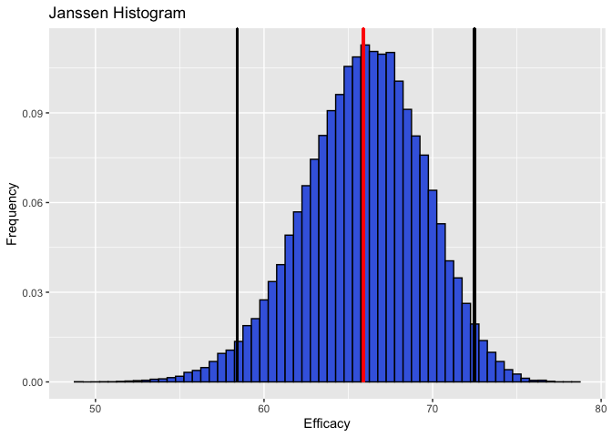

```
##   Mean  Std             C.Interval
## 1 65.9 3.58 min: 58.4    max: 72.5
```

```r
plotPosterior(jans[,"diff_rate"], 0.95, "royalblue", "Janssen Histogram")
```

#### Moderna Vaccine

Define data: for Moderna we have

- 11 cases over 14134 vaccinated people
- 185 cases over 14073 for people who took the placebo

```r
v <- 11
nv <- 14134
p <- 185
np <- 14073

mod <- efficacy_analysis(nv, np, v, p)
```

[output not shown]

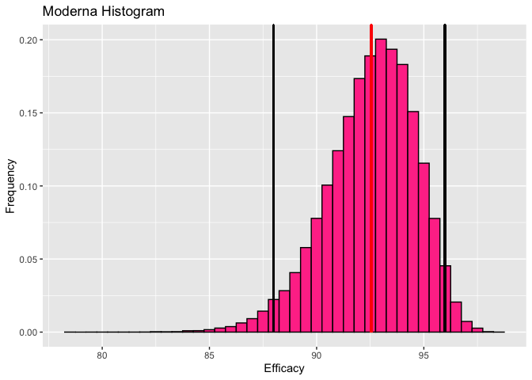

```
##   Mean  Std         C.Interval
## 1 92.5 2.06 min: 88    max: 96
```

```r
plotPosterior(mod[,"diff_rate"], 0.95, "violetred1", "Moderna Histogram")
```

#### Astra-Zeneca Vaccine

Define data: for Astra Zeneca we have

- 64 cases over 5258 vaccinated people
- 154 cases over 5210 for people who took the placebo

```r
v <- 64
nv <- 5258
p <- 154
np <- 5210

AZ <- efficacy_analysis(nv, np, v, p)
```

[output not shown]

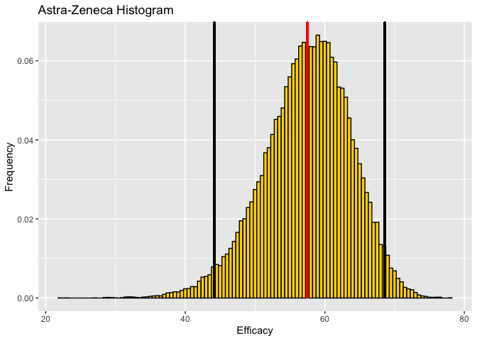

```
##   Mean  Std             C.Interval
## 1 57.5 6.22 min: 44.1    max: 68.6
```

```r
plotPosterior(AZ[,"diff_rate"], 0.95, "gold", "Astra-Zeneca Histogram")
```

## Exercise 3

Warning: In order to perform the analysis you will need to download the file available at (https://ourworldindata.org/covid-vaccinations) and place it in the same folder as this notebook.

```r
data <- read_csv("owid-covid-data.csv")
spec(data)
data2 <- data.frame(data)
```

### Daily Vaccinations

Daily and weekly vaccinations worldwide

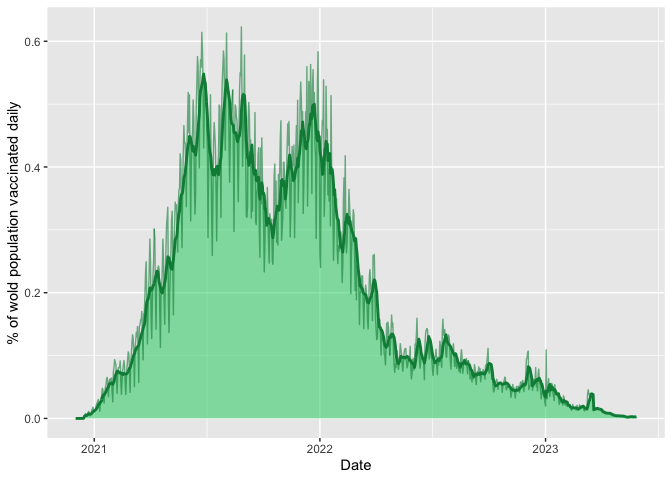

```r
filtdata <- data2[data2$location=="World",c("new_vaccinations","new_vaccinations_smoothed","date","population")] |> drop_na(new_vaccinations_smoothed, population, date) |> group_by(date) |> summarize(nvac = 100 * sum(new_vaccinations_smoothed) / sum(population), nvac2 = 100 * sum(new_vaccinations) / sum(population))

(p <- ggplot(filtdata) + geom_area(aes(date,nvac), alpha=0.5, lwd=1, color="springgreen4", fill="springgreen3") + geom_line(aes(date,nvac2), alpha=0.6, lwd=0.5, color="springgreen4")+ labs(x="Date",y="% of wold population vaccinated daily"))
```

Vaccinated people (green) along with fully vaccinated people (pink)

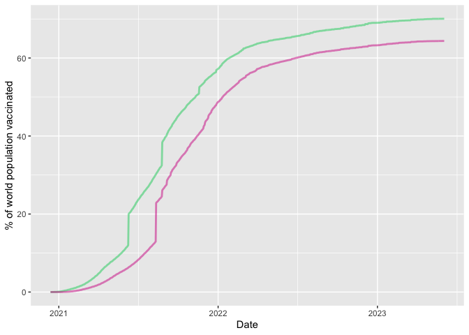

```r
filtdata <- data2[data2$location=="World",c("people_vaccinated_per_hundred", "people_fully_vaccinated_per_hundred","date","population")] |> drop_na(people_vaccinated_per_hundred, people_fully_vaccinated_per_hundred, population, date) |> group_by(date)

(p <- ggplot(filtdata) + geom_line(aes(date,people_vaccinated_per_hundred), alpha=0.5, lwd=1, color="springgreen3") + geom_line(aes(date,people_fully_vaccinated_per_hundred), alpha=0.5, lwd=1, color="violetred") +labs(x="Date",y="% of world population vaccinated"))
```

### Deaths

Death rate

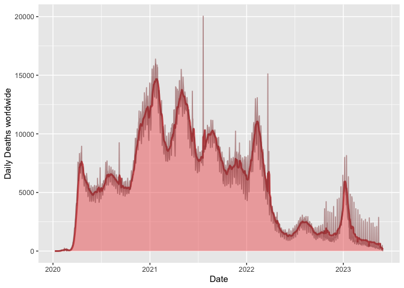

```r
filtdata <- data2[data2$location=="World",c("new_deaths","new_deaths_smoothed","date","population")] |> drop_na(new_deaths_smoothed, date) |> group_by(date)

(p <- ggplot(filtdata) + geom_area(aes(date,new_deaths_smoothed), alpha=0.5, lwd=1, color="indianred3", fill="indianred2")+ geom_line(aes(date,new_deaths), alpha=0.5, lwd=0.6, color="indianred4")+
    labs(x="Date",y="Daily Deaths worldwide"))
```

Total death toll

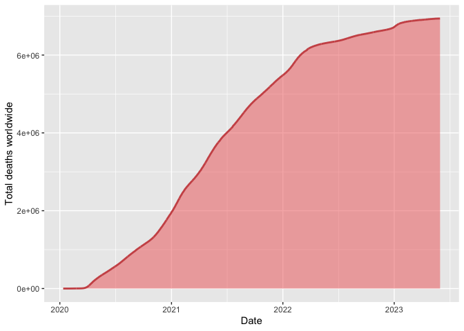

```r
filtdata <- data2[data2$location=="World",c("total_deaths","date","population")] |> drop_na(total_deaths, date) |> group_by(date)

(p <- ggplot(filtdata) + geom_area(aes(date,total_deaths), alpha=0.5, lwd=1, color="indianred3", fill="indianred2")+
    labs(x="Date",y="Total deaths worldwide"))
```